# Python Project - (PROSPER LOAN DATA ANALYSIS)

## QUESTION 1b: Find the income range of borrower in prosper loan company (categorical variable)

```python
df['IncomeRange']
```

```
0         $25,000-49,999
1         $50,000-74,999
2          Not displayed
3         $25,000-49,999
4              $100,000+
               ...
113932    $50,000-74,999
113933    $75,000-99,999
113934    $25,000-49,999
113935    $25,000-49,999
113936    $50,000-74,999
Name: IncomeRange, Length: 113937, dtype: object
```

```python
df['IncomeRange'] = df['IncomeRange'].str.replace('$', '', regex = True)
```

```python
df['IncomeRange'] = df['IncomeRange'].str.replace('Not displayed', '0')
```

```python
df
```

|  | ListingKey | ListingNumber | ListingCreationDate | CreditGrade | Term | LoanStatus | ClosedDate | BorrowerAPR | BorrowerRate | LenderYield | ... | LP_ServiceFees | LP_CollectionFees | LP_GrossPrincipalLoss | LP_NetPrincipalLoss | LP_NonPrincipalRecoverypayments | PercentFunded | Recommendations | InvestmentFromFriendsCount | InvestmentFromFriendsAmount | Investors |
| --- | --- | --- | --- | --- | --- | --- | --- | --- | --- | --- | --- | --- | --- | --- | --- | --- | --- | --- | --- | --- | --- |
| 0 | 1021339766868145413AB3B | 193129 | 09:29.3 | C | 36 | Completed | 14/08/2009 00:00 | 0.16516 | 0.1580 | 0.1380 | ... | -133.18 | 0.0 | 0.0 | 0.0 | 0.0 | 1.0 | 0 | 0 | 0.0 | 258 |
| 1 | 10273602499503308B223C1 | 1209647 | 28:07.9 | NaN | 36 | Current | NaN | 0.12016 | 0.0920 | 0.0820 | ... | 0.00 | 0.0 | 0.0 | 0.0 | 0.0 | 1.0 | 0 | 0 | 0.0 | 1 |
| 2 | 0EE9337825851032864889A | 81716 | 00:47.1 | HR | 36 | Completed | 17/12/2009 00:00 | 0.28269 | 0.2750 | 0.2400 | ... | -24.20 | 0.0 | 0.0 | 0.0 | 0.0 | 1.0 | 0 | 0 | 0.0 | 41 |
| 3 | 0EF5356002482715299901A | 658116 | 02:35.0 | NaN | 36 | Current | NaN | 0.12528 | 0.0974 | 0.0874 | ... | -108.01 | 0.0 | 0.0 | 0.0 | 0.0 | 1.0 | 0 | 0 | 0.0 | 158 |
| 4 | 0F023589499656230C5E3E2 | 909464 | 38:39.1 | NaN | 36 | Current | NaN | 0.24614 | 0.2085 | 0.1985 | ... | -60.27 | 0.0 | 0.0 | 0.0 | 0.0 | 1.0 | 0 | 0 | 0.0 | 20 |
| ... | ... | ... | ... | ... | ... | ... | ... | ... | ... | ... | ... | ... | ... | ... | ... | ... | ... | ... | ... | ... | ... |
| 113932 | E6D9357655724827169606C | 753087 | 55:02.7 | NaN | 36 | Current | NaN | 0.22354 | 0.1864 | 0.1764 | ... | -75.58 | 0.0 | 0.0 | 0.0 | 0.0 | 1.0 | 0 | 0 | 0.0 | 1 |
| 113933 | E6DB353036033497292EE43 | 537216 | 42:55.3 | NaN | 36 | FinalPaymentInProgress | NaN | 0.13220 | 0.1110 | 0.1010 | ... | -30.05 | 0.0 | 0.0 | 0.0 | 0.0 | 1.0 | 0 | 0 | 0.0 | 22 |
| 113934 | E6E13596170052029692BB1 | 1069178 | 49:12.7 | NaN | 60 | Current | NaN | 0.23984 | 0.2150 | 0.2050 | ... | -16.91 | 0.0 | 0.0 | 0.0 | 0.0 | 1.0 | 0 | 0 | 0.0 | 119 |
| 113935 | E6EB3531504622671970D9E | 539056 | 18:26.6 | NaN | 60 | Completed | 13/08/2013 00:00 | 0.28408 | 0.2605 | 0.2505 | ... | -235.05 | 0.0 | 0.0 | 0.0 | 0.0 | 1.0 | 0 | 0 | 0.0 | 274 |
| 113936 | E6ED3600409833199F711B7 | 1140093 | 27:37.7 | NaN | 36 | Current | NaN | 0.13189 | 0.1039 | 0.0939 | ... | -1.70 | 0.0 | 0.0 | 0.0 | 0.0 | 1.0 | 0 | 0 | 0.0 | 1 |

113937 rows × 81 columns

> **Tip**: Visualizations should depict the data appropriately so that the plots are easily interpretable. You should choose an appropriate plot type, data encodings, and formatting as needed. The formatting may include setting/adding the title, labels, legend, and comments. Also, do not overplot or incorrectly plot data.

```python
df['IncomeRange'] = df['IncomeRange'].str.replace('Not Employed', '0')
```

```python
df
```

|  | ListingKey | ListingNumber | ListingCreationDate | CreditGrade | Term | LoanStatus | ClosedDate | BorrowerAPR | BorrowerRate | LenderYield | ... | LP_ServiceFees | LP_CollectionFees | LP_GrossPrincipalLoss | LP_NetPrincipalLoss | LP_NonPrincipalRecoverypayments | PercentFunded | Recommendations | InvestmentFromFriendsCount | InvestmentFromFriendsAmount | Investors |
| --- | --- | --- | --- | --- | --- | --- | --- | --- | --- | --- | --- | --- | --- | --- | --- | --- | --- | --- | --- | --- | --- |
| 0 | 1021339766868145413AB3B | 193129 | 09:29.3 | C | 36 | Completed | 14/08/2009 00:00 | 0.16516 | 0.1580 | 0.1380 | ... | -133.18 | 0.0 | 0.0 | 0.0 | 0.0 | 1.0 | 0 | 0 | 0.0 | 258 |
| 1 | 10273602499503308B223C1 | 1209647 | 28:07.9 | NaN | 36 | Current | NaN | 0.12016 | 0.0920 | 0.0820 | ... | 0.00 | 0.0 | 0.0 | 0.0 | 0.0 | 1.0 | 0 | 0 | 0.0 | 1 |
| 2 | 0EE9337825851032864889A | 81716 | 00:47.1 | HR | 36 | Completed | 17/12/2009 00:00 | 0.28269 | 0.2750 | 0.2400 | ... | -24.20 | 0.0 | 0.0 | 0.0 | 0.0 | 1.0 | 0 | 0 | 0.0 | 41 |
| 3 | 0EF5356002482715299901A | 658116 | 02:35.0 | NaN | 36 | Current | NaN | 0.12528 | 0.0974 | 0.0874 | ... | -108.01 | 0.0 | 0.0 | 0.0 | 0.0 | 1.0 | 0 | 0 | 0.0 | 158 |
| 4 | 0F023589499656230C5E3E2 | 909464 | 38:39.1 | NaN | 36 | Current | NaN | 0.24614 | 0.2085 | 0.1985 | ... | -60.27 | 0.0 | 0.0 | 0.0 | 0.0 | 1.0 | 0 | 0 | 0.0 | 20 |
| ... | ... | ... | ... | ... | ... | ... | ... | ... | ... | ... | ... | ... | ... | ... | ... | ... | ... | ... | ... | ... | ... |
| 113932 | E6D9357655724827169606C | 753087 | 55:02.7 | NaN | 36 | Current | NaN | 0.22354 | 0.1864 | 0.1764 | ... | -75.58 | 0.0 | 0.0 | 0.0 | 0.0 | 1.0 | 0 | 0 | 0.0 | 1 |
| 113933 | E6DB353036033497292EE43 | 537216 | 42:55.3 | NaN | 36 | FinalPaymentInProgress | NaN | 0.13220 | 0.1110 | 0.1010 | ... | -30.05 | 0.0 | 0.0 | 0.0 | 0.0 | 1.0 | 0 | 0 | 0.0 | 22 |
| 113934 | E6E13596170052029692BB1 | 1069178 | 49:12.7 | NaN | 60 | Current | NaN | 0.23984 | 0.2150 | 0.2050 | ... | -16.91 | 0.0 | 0.0 | 0.0 | 0.0 | 1.0 | 0 | 0 | 0.0 | 119 |
| 113935 | E6EB3531504622671970D9E | 539056 | 18:26.6 | NaN | 60 | Completed | 13/08/2013 00:00 | 0.28408 | 0.2605 | 0.2505 | ... | -235.05 | 0.0 | 0.0 | 0.0 | 0.0 | 1.0 | 0 | 0 | 0.0 | 274 |
| 113936 | E6ED3600409833199F711B7 | 1140093 | 27:37.7 | NaN | 36 | Current | NaN | 0.13189 | 0.1039 | 0.0939 | ... | -1.70 | 0.0 | 0.0 | 0.0 | 0.0 | 1.0 | 0 | 0 | 0.0 | 1 |

113937 rows × 81 columns

```python
df['IncomeRange']
```

[output not shown]

```python
df['IncomeRange'] = df['IncomeRange'].str.replace('Notemployed', '0')
```

```python
df.IncomeRange
```

[output not shown]

```python
df['IncomeRange'] = df['IncomeRange'].str.replace(' ', '-')
```

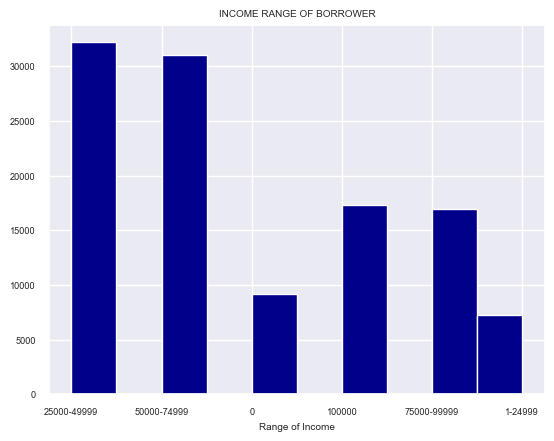

```python
plt.hist(data = df, x = 'IncomeRange', color = '#00008B');
plt.title('INCOME RANGE OF BORROWER')
plt.xlabel('Range of Income')
```

OBSERVATION: The histogram chart with precision , depict the ranges of income of borrower in 'PROSPER LOAN COMPANY'. it is pertinent to note that this feature i.e 'INCOME RANGE' is one of the effective yardstick adopted by most loan and financial institution to determine the financial credibility of both prospective and existing .

### Of the features you investigated, were there any unusual distributions? Did you perform any operations on the data to tidy, adjust, or change the form of the data? If so, why did you do this?

> ANSWER: Some data cleaning where carried out on this particular feature/variable (INCOME RANGE). Some of the value are non numerical, thus in order to ensure consistency in this dataset , i replace this following strings value 'NOT DISPLAYED', 'NOT EMPPLOYED' with 0.

## QUESTION 2; EFFECT OF BORROWER EMPLOYMENT STATUS ON MONTHLY LOAN REPAYMENT (CATEGORICAL AND QUANTITATIVE VARIABLES)

```python
import matplotlib.pyplot as plt
```

```python
df['EmploymentStatus'] = df['EmploymentStatus'].replace('blank', ' ')
```

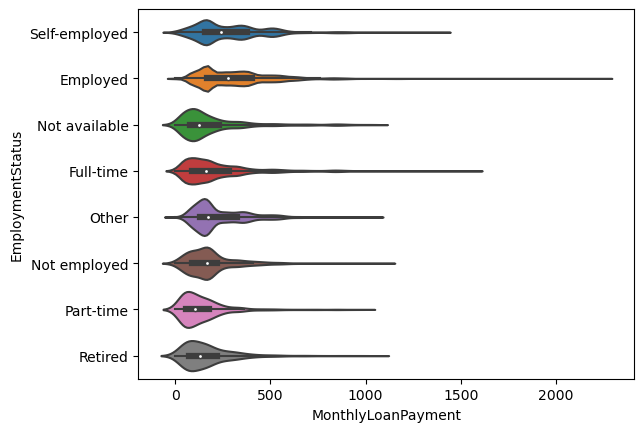

```python
sns.violinplot(data = df, x="MonthlyLoanPayment", y="EmploymentStatus", Font_scale = -24)
plt.figure(figsize=(0, 0));
```

## QUESTION 3: DOES THE INTEREST RATE HAS ANY CORRELATION WITH THE MONTHLY LOAN PAYMENT (2 QUANTITATIVE VARIABLE).

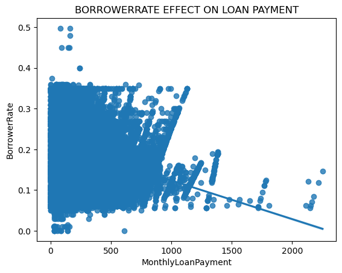

```python
sns.regplot(data = df, x='MonthlyLoanPayment', y='BorrowerRate', fit_reg = 'false');
plt.title('BORROWERRATE EFFECT ON LOAN PAYMENT')
```

## QUESTION 4:

```python
df['MonthlyLoanPayment'].mean()
```

```
272.47578310823104
```

```python
import numpy as np
```

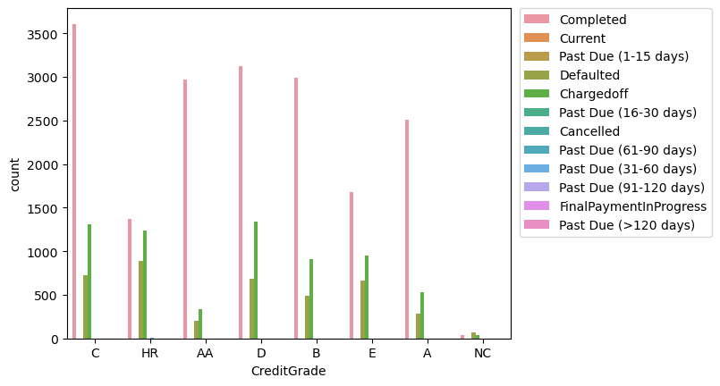

```python
sns.countplot(data = df, x="CreditGrade", hue = "LoanStatus");
plt.legend(bbox_to_anchor=(1.02, 1), loc='upper left', borderaxespad=0);
```

## Conclusions

Interest rate on loan are also drill down as prosper loan financial service recover more loan from their borrower.